# Praca domowa 2

Leonard Lorenc

## Dane

Dane wykorzystane w Pracy domowej 2 dotyczą wyników egzaminów z 3 umiejętności: czytania, pisania i operacji matematycznych. Dodatkowo dostępne są podstawowe informacje o studentach i ich rodzicach. Opis wszystkich kolumn znajduje się również w pliku `README.md`.

| Zmienna | Opis |
| --- | --- |
| **gender** | płeć |
| **race.ethnicity** | pochodzenie etniczne |
| **parental.level.of.education** | wykształcenie rodziców |
| **lunch** | jaki obiad jedli uczniowie w dniu egzaminu |
| **test.preparation.course** | czy uczeń odbył kurs przygotowujący |
| **math.score** | wynik egzaminu z matematyki |
| **reading.score** | wynik egzaminu z czytania |
| **writing.score** | wynik egzaminu z pisania |

## Zadanie 1

Jak wyglądają rozkłady wyników uczniów z trzech przedmiotów (matematyka, czytanie, pisanie)?

```r
# Tu umieść kod do wygenerowania odpowiedzi do zadania.
grupy<- rep("math",dim(df)[1])
grupy<- c(grupy,rep("reading",dim(df)[1]))
grupy<- c(grupy,rep("writing",dim(df)[1]))
wyniki <- df %>% select(math.score,writing.score,reading.score)
summary(wyniki)
```

```
##    math.score     writing.score    reading.score
##  Min.   :  0.00   Min.   : 10.00   Min.   : 17.00
##  1st Qu.: 57.00   1st Qu.: 57.75   1st Qu.: 59.00
##  Median : 66.00   Median : 69.00   Median : 70.00
##  Mean   : 66.09   Mean   : 68.05   Mean   : 69.17
##  3rd Qu.: 77.00   3rd Qu.: 79.00   3rd Qu.: 79.00
##  Max.   :100.00   Max.   :100.00   Max.   :100.00
```

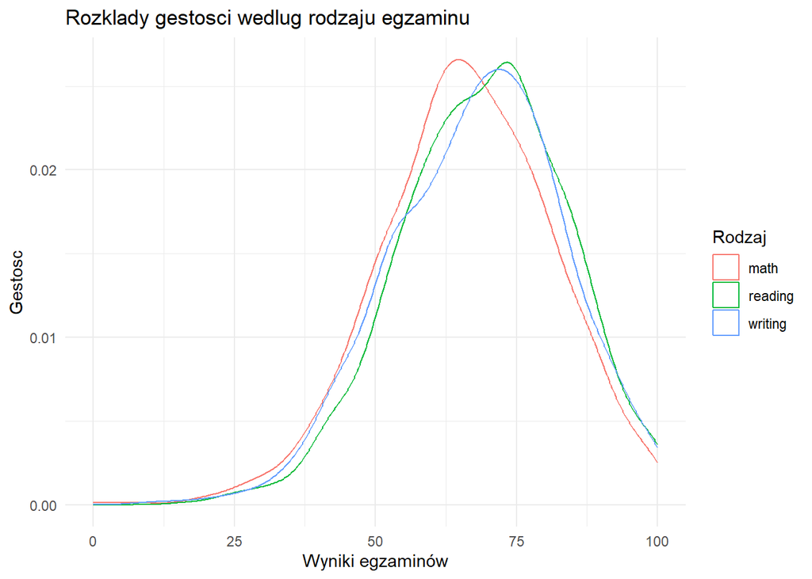

```r
do_wykresu <-c(df$math.score,df$reading.score,df$writing.score)

do_wykresu<-cbind(do_wykresu,grupy)
colnames(do_wykresu)<-c("wynik","rodzaj")
do_wykresu<-data.frame(do_wykresu)
do_wykresu<-do_wykresu %>% mutate(wynik = as.numeric(wynik))

do_wykresu %>% ggplot(aes(x = wynik,group=rodzaj,color=rodzaj))+
  geom_density()+ labs(
    title = "Rozklady gestosci wedlug rodzaju egzaminu",
    x = "Wyniki egzaminów",
    y = "Gestosc",
    color = "Rodzaj")+
  theme_minimal()
```

**Komentarz:** #Możemy zobaczyć że mediany i średnie dla writing i reading są mniej więcej takie same jednak # math ma trochę niższe i jednocześnie w math.score pojawiają się wyniki równe 0 #jednak ogólny rozkład wyników jest bardzo podobny co widać po różnicach Q3 - Q1

## Zadanie 2

Czy istnieje zauważalna różnica w wynikach między uczniami i uczennicami?

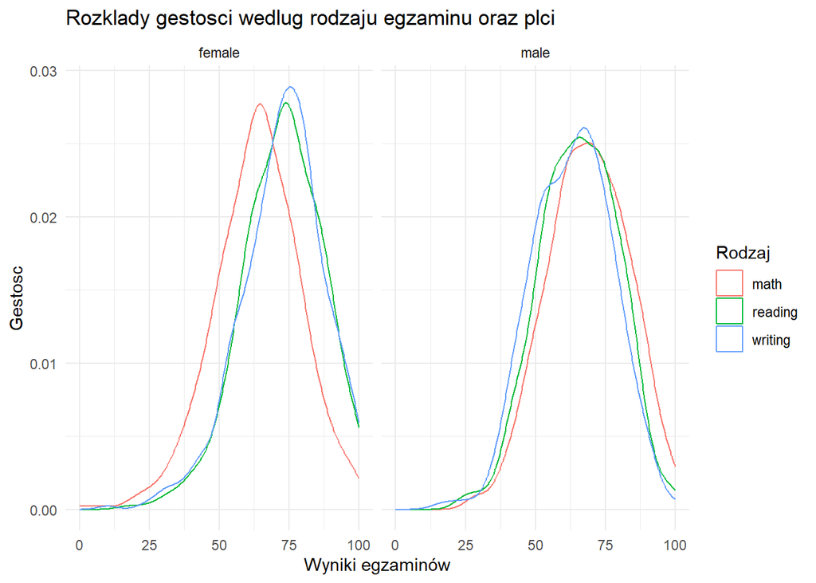

```r
# Tu umieść kod do wygenerowania odpowiedzi do zadania.
do_wykresu_plec<- cbind(do_wykresu,gender =df$gender)

do_wykresu_plec %>%ggplot(aes(x = wynik,group=rodzaj,color=rodzaj))+
  geom_density()+facet_wrap(~ gender)+labs(
    title = "Rozklady gestosci wedlug rodzaju egzaminu oraz plci",
    x = "Wyniki egzaminów",
    y = "Gestosc",
    color = "Rodzaj")+
  theme_minimal()
```

```r
do_wykresu_plec %>% group_by(gender,rodzaj) %>%  summarise(
    across(
      where(is.numeric),
      list(
        mean = ~mean(.),
        q1   = ~quantile(., 0.25),
        median = ~median(.),
        q3   = ~quantile(., 0.75),
        min  = ~min(.),
        max  = ~max(.)
      ),
      .names = "{.col}_{.fn}"
    ))
```

```
## # A tibble: 6 × 8
## # Groups:   gender [2]
##   gender rodzaj  wynik_mean wynik_q1 wynik_median wynik_q3 wynik_min wynik_max
##   <chr>  <chr>        <dbl>    <dbl>        <dbl>    <dbl>     <dbl>     <dbl>
## 1 female math          63.6     54             65     74           0       100
## 2 female reading       72.6     63.2           73     83          17       100
## 3 female writing       72.5     64             74     82          10       100
## 4 male   math          68.7     59             69     79          27       100
## 5 male   reading       65.5     56             66     75          23       100
## 6 male   writing       63.3     53             64     73.8        15       100
```

## Zadanie 3

Czy uczniowie, którzy ukończyli kurs przygotowawczy, osiągają lepsze wyniki niż pozostali?

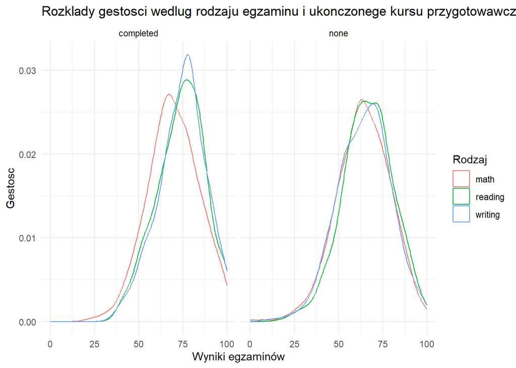

```r
# Tu umieść kod do wygenerowania odpowiedzi do zadania.
do_wykresu_kurs <- cbind(do_wykresu,kurs=df$test.preparation.course)

do_wykresu_kurs %>%ggplot(aes(x = wynik,group=rodzaj,color=rodzaj))+
  geom_density()+facet_wrap(~ kurs)+ labs(
    title = "Rozklady gestosci wedlug rodzaju egzaminu i ukonczonege kursu przygotowawczego",
    x = "Wyniki egzaminów",
    y = "Gestosc",
    color = "Rodzaj")+
  theme_minimal()
```

```r
do_wykresu_kurs %>% group_by(kurs,rodzaj) %>%  summarise(
    across(
      where(is.numeric),
      list(
        mean = ~mean(.),
        q1   = ~quantile(., 0.25),
        median = ~median(.),
        q3   = ~quantile(., 0.75),
        min  = ~min(.),
        max  = ~max(.)
      ),
      .names = "{.col}_{.fn}"
    )
  )
```

```
## # A tibble: 6 × 8
## # Groups:   kurs [2]
##   kurs      rodzaj wynik_mean wynik_q1 wynik_median wynik_q3 wynik_min wynik_max
##   <chr>     <chr>       <dbl>    <dbl>        <dbl>    <dbl>     <dbl>     <dbl>
## 1 completed math         69.7       60           69     79          23       100
## 2 completed readi…       73.9       65           75     84          37       100
## 3 completed writi…       74.4       66           76     83          36       100
## 4 none      math         64.1       54           64     74.8         0       100
## 5 none      readi…       66.5       57           67     76          17       100
## 6 none      writi…       64.5       54           65     74          10       100
```

**Komentarz:** # Tak uczniowie po kursie osiągają lepsze wyniki zarówno mediana i średnie ze wszystkich przedmiotów są wyższe , i np jeśli przyjmiemy próg zdawalności 30 punktów to wszyscy po kursie zdali pisanie i czytanie czego nie można powiedzieć o tych bez kursu

## Zadanie 4

Jaki jest związek między poziomem wykształcenia rodziców a średnimi wynikami uczniów?

```r
# Tu umieść kod do wygenerowania odpowiedzi do zadania.
do_wykresu_rodz<- cbind(do_wykresu,wyk_rodzica = df$parental.level.of.education)

do_wykresu_rodz<- do_wykresu_rodz %>% group_by(wyk_rodzica,rodzaj) %>%
  summarise(srednia = mean(wynik))
do_wykresu_rodz
```

```
## # A tibble: 18 × 3
## # Groups:   wyk_rodzica [6]
##    wyk_rodzica        rodzaj  srednia
##    <chr>              <chr>     <dbl>
##  1 associate's degree math       67.9
##  2 associate's degree reading    70.9
##  3 associate's degree writing    69.9
##  4 bachelor's degree  math       69.4
##  5 bachelor's degree  reading    73
##  6 bachelor's degree  writing    73.4
##  7 high school        math       62.1
##  8 high school        reading    64.7
##  9 high school        writing    62.4
## 10 master's degree    math       69.7
## 11 master's degree    reading    75.4
## 12 master's degree    writing    75.7
## 13 some college       math       67.1
## 14 some college       reading    69.5
## 15 some college       writing    68.8
## 16 some high school   math       63.5
## 17 some high school   reading    66.9
## 18 some high school   writing    64.9
```

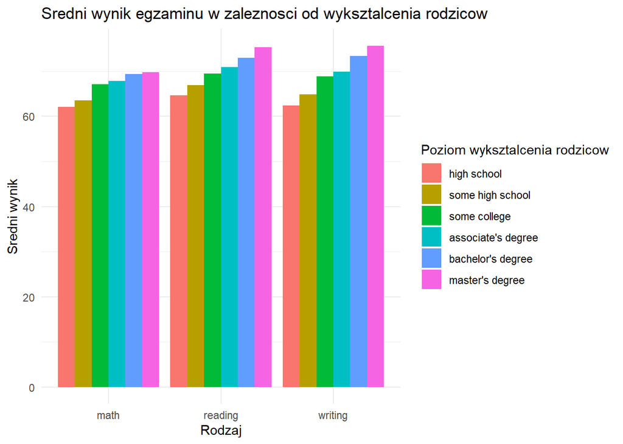

```r
do_wykresu_rodz %>% ggplot(aes(x=rodzaj,y=srednia,fill=reorder(wyk_rodzica,srednia)))+
  geom_bar(position="dodge",stat="identity")+ labs(
    title = "Sredni wynik egzaminu w zaleznosci od wyksztalcenia rodzicow",
    x = "Rodzaj",
    y = "Sredni wynik",
    fill = "Poziom wyksztalcenia rodzicow")+
  theme_minimal()
```

**Komentarz:** ## srednie wyniki wydają się rosnąc jak zwiększa się wykształcenie rodziców największy wpływ ma to na wyniki z pisania i czytania

## Zadanie 5

Czy płeć i wykształcenie rodzica wpływa na wynik z matematyki?

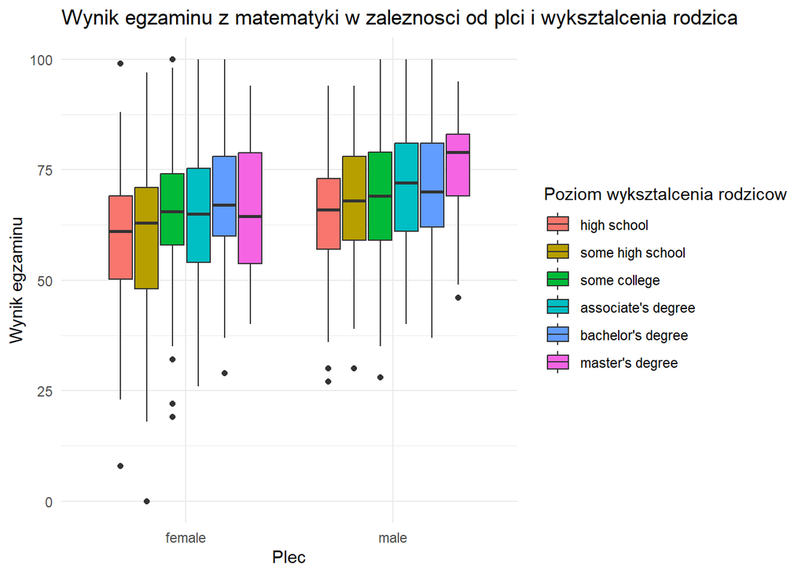

```r
# Tu umieść kod do wygenerowania odpowiedzi do zadania.
plec_wyk <- df %>% select(math.score,parental.level.of.education,gender)
plec_wyk %>% ggplot(aes(x = gender,y=math.score,fill=reorder(parental.level.of.education,math.score,fun=mean)))+
  geom_boxplot()+ labs(
    title = "Wynik egzaminu z matematyki w zaleznosci od plci i wyksztalcenia rodzica",
    x = "Plec",
    y = "Wynik egzaminu",
    fill = "Poziom wyksztalcenia rodzicow")+
    theme_minimal()
```

## Zadanie 6

Czy istnieje zależność między wynikami z matematyki a wynikami z czytania lub pisania?

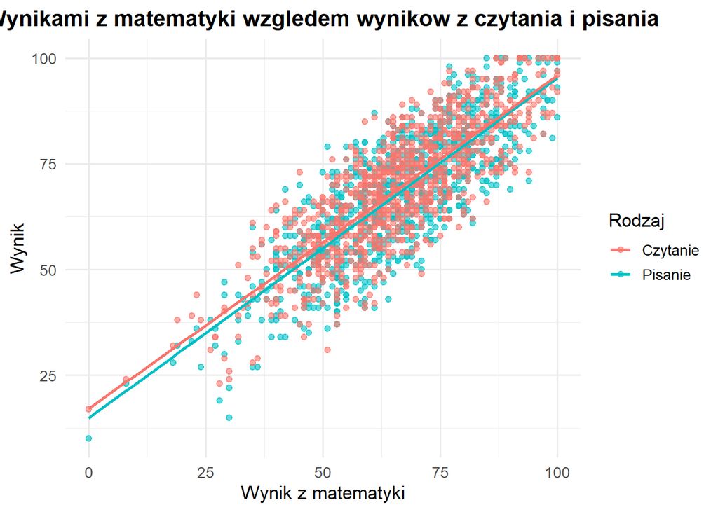

```r
# Tu umieść kod do wygenerowania odpowiedzi do zadania.


df %>%
  ggplot() +
  geom_point(aes(x = math.score, y = writing.score, color = "Pisanie"), alpha = 0.6) +
  geom_point(aes(x = math.score, y = reading.score, color = "Czytanie"), alpha = 0.6) +

  # add linear trends for both relationships
  geom_smooth(aes(x = math.score, y = writing.score, color = "Pisanie"),
              method = "lm", se = FALSE, linewidth = 1) +
  geom_smooth(aes(x = math.score, y = reading.score, color = "Czytanie"),
              method = "lm", se = FALSE, linewidth = 1) +

  labs(
    title = "Wynikami z matematyki wzgledem wynikow z czytania i pisania",
    x = "Wynik z matematyki",
    y = "Wynik",
    color = "Rodzaj"
  ) +
  theme_minimal(base_size = 13) +
  theme(
    plot.title = element_text(face = "bold", hjust = 0.5),
    legend.position = "right"
  )
```

**Komentarz:** # Relacja pomiedzy przedmiotami jest liniowa i prawie taka sama